# WeRateDogs Twitter Data Report (Visualizing & Communicates insights)

**By Abdulrahman Almajhad**

## 1. Introduction

The WeRateDogs dataset that we will be visualizing and communicates insight is the tweet archive of Twitter user @dog_rates, also known as WeRateDogs. WeRateDogs is a Twitter account that rates people's dogs with a humorous comment about the dog.

By using Python and its libraries, we will visualize and communicates insight in a variety of charts, we will document our efforts in this Jupyter Notebook.

## 2. Visualizations

In this section, we will visualize some of the charts that we used for our analysis.

```python
import pandas as pd
import numpy as np
import matplotlib.pyplot as plt
import seaborn as sns
%matplotlib inline
```

```python
df_twitter_master = pd.read_csv('twitter_archive_master.csv')
```

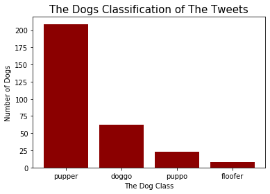

```python
plt.bar(df_twitter_master['dog_class'].value_counts().index, df_twitter_master['dog_class'].value_counts(), color='darkred')
plt.xlabel('The Dog Class')
plt.ylabel('Number of Dogs')
plt.title('The Dogs Classification of The Tweets', fontsize = 15);
```

> **The `pupper` dogs is the highest dog class, then `doggo`, `puppo` and `floofer`**

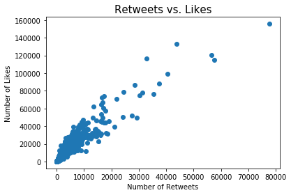

```python
plt.scatter(df_twitter_master['retweets'], df_twitter_master['likes'])
plt.xlabel('Number of Retweets')
plt.ylabel('Number of Likes')
plt.title('Retweets vs. Likes', fontsize = 15);
```

> **There is a positave correlation between number of retweets and number of likes**

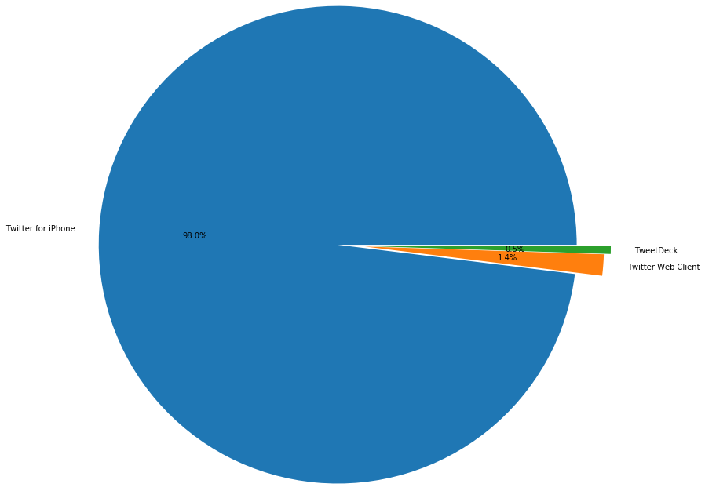

```python
labels = 'Twitter for iPhone', 'Twitter Web Client', 'TweetDeck'

plt.pie(df_twitter_master['source'].value_counts(), explode=(0.3, 0.1, 0.2), labels=labels, autopct='%1.1f%%', radius=3.5);
```

## 3. Insights

In this section, we will show you the all insights that we got from analysis and visualizations (charts). Which are in the following:

- The highest number of retweets is **77572**, and the highest number of likes is **155747**, which both on the same tweet! the tweet with ID: **744234799360020481**.
- The average retweet of all tweets is **2464**, and the average likes is **8309**.
- The **pupper** dogs are the most dogs we have, compared with all dogs classifications.
- Most tweets have been sent by **iPhone**! by **98%**.
- The tweets interval is from **2015-11-15** until **2017-08-01**.
- The average rating of all tweets is about **11.65/10**.
- There is a positive correlation between retweets and likes.

## 4. Conclusion

In conclusion, we visualized some of the data after we analyzed it. Then we got some of the insights from the analysis and visualizations.